# CMP713 Data Mining

## 2026-2027 Fall - Assignment 1

## Given 09/11/2026, Due 15/11/2026 (23:59)

| Name | ID | Points | Task1 | Task2 | Task3 | Task4 | Total |
| --- | --- | --- | --- | --- | --- | --- | --- |
| Erkani Mert Tosun | 25123091 | Max | 10 | 6 | 7 | 7 | 30 |
|  |  | Given | 0 | 0 | 0 | 0 | 0 |

In this assignment you will work on the data of the **Meltem wind farm**: 12 turbines, 5 years, one record per turbine per day (`meltem_daily.csv`). Read the data dictionary (`meltem_dictionary.md`) first, then look at the data before you compute anything. The four tasks use what we learned in Lectures 4-7: missing values, sampling, time series components and exploratory analysis.

**Rules**

- Do not change anything in this document, other than `student_name` and `student_id` in the chunk above, and the Answer sections below.
- You will submit **only your Rmd file**. I will knit it myself, in a folder that contains `meltem_daily.csv`. So it must run from top to bottom without errors in less than 5 minutes, and it must read the data with the relative file name used in the fixed code. The last chunk of this document collects your objects `imputed` and `split` when it is knitted; knit it yourself first and check that the table at the end shows both.
- Nobody tells you which method to use. Choose your methods, and **explain and justify your choices** in the places marked *Explanation*. A good explanation refers to what you saw in *this* data (a number, a plot) and not to general statements. Generic explanations receive little credit. Respect the word limits.
- Your code must run from top to bottom without errors. Never install new packages. Only the packages we have shown in the course are allowed: `dplyr`, `tidyr`, `readr`, `ggplot2`, `DMwR2`, `mice` and base R.
- You may use AI tools, but you alone are responsible for what you submit. Read the data, and check what the tools do.

**Which data?** `meltem` is the original table as it was given. Only Task 1 produces an imputed table (`imputed`). Tasks 2, 3 and 4 work on the original `meltem`, not on `imputed`: the columns they use (`date`, `turbine`, `fault_next7`, `energy_mwh`, `rotor_rpm`, `gbx_oil_c`) have no gaps, so imputation does not matter there. In Task 1 work on a copy of `meltem` and leave `meltem` itself unchanged.

Good luck!

### Fixed code (do not change)

```r
library(dplyr); library(tidyr); library(readr); library(ggplot2); library(DMwR2); library(mice)
my_seed <- as.numeric(student_id) %% 1000003
meltem  <- read_csv("meltem_daily.csv", show_col_types = FALSE)   # 21,924 rows, 34 columns
dim(meltem)
```

```
## [1] 21924    34
```

### TASK 1: Missing values (10 points)

`meltem` has missing values. Find all of them and impute them.

Work on a copy of `meltem` and put your result in a data frame named `imputed`, which has the same rows and the same columns as `meltem`. Your imputed values will be compared with the true values (that only the instructor knows): the closer you are, the more points you get. You can lose up to 5 points if you do not explain properly what you did and why.

#### Answer

```r
set.seed(my_seed)
imputed <- meltem
rmse <- function(p, a) sqrt(mean((p - a)^2))

# ---- 1. Where are the gaps? ----
colSums(is.na(imputed))[colSums(is.na(imputed)) > 0]
```

```
##   gen_temp_c vib_gbx_mm_s
##         1381          990
```

```r
summary(imputed$wind_ms)            # min = -9999: an impossible wind speed, a hidden NA
```

```
##     Min.  1st Qu.   Median     Mean  3rd Qu.     Max.
## -9999.00     5.62     7.16  -500.72     8.58    14.29
```

```r
sum(imputed$wind_ms == -9999)
```

```
## [1] 1113
```

```r
imputed$wind_ms <- na_if(imputed$wind_ms, -9999)
max(imputed$vib_gbx_mm_s, na.rm = TRUE)   # exactly 9 = the end of the sensor range (dictionary)
```

```
## [1] 9
```

```r
# ---- 2. Why are they missing? ----
imputed %>% group_by(month = format(date, "%m")) %>%
  summarise(wind = mean(is.na(wind_ms)), gen_temp = mean(is.na(gen_temp_c)), vib = mean(is.na(vib_gbx_mm_s))) %>%
  mutate(across(-month, ~ round(.x, 3))) %>% print(n = 12)
```

```
## # A tibble: 12 × 4
##    month  wind gen_temp   vib
##    <chr> <dbl>    <dbl> <dbl>
##  1 01    0.053    0.22  0.016
##  2 02    0.048    0.158 0.01
##  3 03    0.052    0.092 0.016
##  4 04    0.042    0.042 0.013
##  5 05    0.052    0.011 0.056
##  6 06    0.059    0     0.088
##  7 07    0.051    0     0.13
##  8 08    0.059    0.005 0.127
##  9 09    0.049    0.004 0.034
## 10 10    0.052    0.015 0.019
## 11 11    0.043    0.072 0.023
## 12 12    0.051    0.141 0.006
```

```r
imputed %>% group_by(gen_temp_missing = is.na(gen_temp_c)) %>% summarise(ambient_c = mean(ambient_c), n = n())
```

```
## # A tibble: 2 × 3
##   gen_temp_missing ambient_c     n
##   <lgl>                <dbl> <int>
## 1 FALSE                15.4  20543
## 2 TRUE                  6.89  1381
```

```r
imputed %>% group_by(vib_missing = is.na(vib_gbx_mm_s)) %>% summarise(energy_mwh = mean(energy_mwh), gbx_brg_c = mean(gbx_brg_c), n = n())
```

```
## # A tibble: 2 × 4
##   vib_missing energy_mwh gbx_brg_c     n
##   <lgl>            <dbl>     <dbl> <int>
## 1 FALSE             18.1      57.0 20934
## 2 TRUE              40.3      71.4   990
```

```r
# ---- 3. Which method is best? Hide known values, impute them, compare with the truth (RMSE) ----
d <- imputed %>% select(where(is.numeric), -fault_next7) %>% as.data.frame()
d$turbine <- factor(imputed$turbine)
gaps <- c("wind_ms", "gen_temp_c", "vib_gbx_mm_s")
hid <- list(wind_ms = sample(which(!is.na(d$wind_ms)), 1000),                       # wind gaps: single days
            gen_temp_c = unlist(lapply(sample(which(!is.na(d$gen_temp_c)), 150), function(i) i:(i + 6))))  # gen gaps: blocks of days
hid$gen_temp_c <- unique(hid$gen_temp_c[hid$gen_temp_c <= nrow(d)])   # blocks may overlap: count each day once
hid$gen_temp_c <- hid$gen_temp_c[!is.na(d$gen_temp_c[hid$gen_temp_c])]
holed <- d; for (v in names(hid)) holed[[v]][hid[[v]]] <- NA

lm_fill <- function(data, v) {            # method: linear regression on all complete columns
  fit <- lm(as.formula(paste(v, "~ . -", paste(setdiff(gaps, v), collapse = " - "))), data)
  predict(fit, data)
}
# method: regression + correction of its error (residual)
same_day <- function(res, date) ave(res, date, FUN = function(z) mean(z, na.rm = TRUE))           # wind: mean residual of the other turbines on the same day
in_time  <- function(res, turbine) ave(res, turbine, FUN = function(z) approx(seq_along(z), z, seq_along(z), rule = 2)$y)  # gen_temp: residual interpolated from the neighbouring days

kn <- knnImputation(holed[, names(holed) != "turbine"], k = 10)   # method: kNN imputation (10 nearest rows)
p_w <- lm_fill(holed, "wind_ms");    r_w <- holed$wind_ms - p_w
p_g <- lm_fill(holed, "gen_temp_c"); r_g <- holed$gen_temp_c - p_g
score <- function(v, p) rmse(p[hid[[v]]], d[[v]][hid[[v]]])     # RMSE on the hidden values only
# compare: median, kNN, regression, regression + correction
rbind(wind_ms    = c(median = score("wind_ms", median(holed$wind_ms, na.rm = TRUE) + 0 * p_w), knn = score("wind_ms", kn$wind_ms),
                     lm = score("wind_ms", p_w), lm_corrected = score("wind_ms", p_w + same_day(r_w, imputed$date))),
      gen_temp_c = c(median = score("gen_temp_c", median(holed$gen_temp_c, na.rm = TRUE) + 0 * p_g), knn = score("gen_temp_c", kn$gen_temp_c),
                     lm = score("gen_temp_c", p_g), lm_corrected = score("gen_temp_c", p_g + in_time(r_g, imputed$turbine)))) %>% round(2)
```

```
##            median  knn   lm lm_corrected
## wind_ms      2.07 0.55 0.56         0.34
## gen_temp_c   7.00 1.84 1.22         0.90
```

```r
# vib is cut at 9: test the idea by pretending the sensor stopped at 8
# compare: regression, regression but at least the sensor limit (pmax), median
v8 <- d; truth <- v8$vib_gbx_mm_s; cut8 <- !is.na(truth) & truth > 8; v8$vib_gbx_mm_s[cut8] <- NA
p_v8 <- lm_fill(v8, "vib_gbx_mm_s")
c(lm = rmse(p_v8[cut8], truth[cut8]), lm_at_least_8 = rmse(pmax(p_v8, 8)[cut8], truth[cut8]), median_known = rmse(median(v8$vib_gbx_mm_s, na.rm = TRUE), truth[cut8])) %>% round(2)
```

```
##            lm lm_at_least_8  median_known
##          0.90          0.45          1.88
```

```r
# ---- 4. Impute with the chosen methods ----
# wind_ms: regression + same-day correction; gen_temp_c: regression + time correction; vib_gbx_mm_s: regression, at least 9
p <- lm_fill(d, "wind_ms")
d$wind_ms <- ifelse(is.na(d$wind_ms), p + same_day(d$wind_ms - p, imputed$date), d$wind_ms)
p <- lm_fill(d, "gen_temp_c")
d$gen_temp_c <- ifelse(is.na(d$gen_temp_c), p + in_time(d$gen_temp_c - p, imputed$turbine), d$gen_temp_c)
p <- lm_fill(d, "vib_gbx_mm_s")
d$vib_gbx_mm_s <- ifelse(is.na(d$vib_gbx_mm_s), pmax(p, 9), d$vib_gbx_mm_s)
summary(d$vib_gbx_mm_s[is.na(imputed$vib_gbx_mm_s)])
```

```
##    Min. 1st Qu.  Median    Mean 3rd Qu.    Max.
##   9.000   9.000   9.000   9.046   9.000   9.965
```

```r
imputed[gaps] <- d[gaps]
c(same_dim = identical(dim(imputed), dim(meltem)), any_na = anyNA(imputed))
```

```
## same_dim   any_na
##     TRUE    FALSE
```

#### Explanation (at most 250 words)

For every column that has gaps: what is the problem with its gaps, which method did you choose and why, and how did you check that your choice is good?

I compared methods by hiding known values, imputing them and measuring the error (RMSE).

**wind_ms** had no NAs, but 1,113 values were -9999, an impossible wind speed, so I converted them to NA with `na_if`. The missingness seems MCAR: about 5% in every month. Regression and kNN performed similarly (0.56 and 0.55). Since all turbines see the same wind on the same day, I corrected the regression predictions with the average residual of the other turbines on that day. On 1,000 hidden values, this reduced the RMSE to 0.34, compared with 2.07 for the median.

**gen_temp_c** had 1,381 NAs. The missingness seems MAR: 22% of January is missing but 0% of June, in blocks of days, when the outside air is cold (6.9 vs 15.4 °C). A median would therefore be biased. The regression residuals of nearby days were similar, so I interpolated them over time. On hidden 7-day blocks this gave an RMSE of 0.90, better than regression alone (1.22), kNN (1.84) and the median (7.00).

**vib_gbx_mm_s** had 990 NAs and appears MNAR. The sensor range is 0–9 mm/s, the largest value is exactly 9, and the gaps occur on high-production days (40 vs 18 MWh). So I suspected that these values exceeded the sensor limit. To test this, I simulated a limit of 8: the regression RMSE dropped from 0.90 to 0.45 with `pmax(prediction, 8)`, compared with 1.88 for the median. I therefore used `pmax(regression, 9)` for the real gaps.

### TASK 2: A fair training/test split (6 points)

We want to build a model that predicts the target `fault_next7` from the other columns. You do **not** build the model. Create a training sample and a test sample from the original `meltem` table for this purpose. Start your code with `set.seed(my_seed)`.

Put your result in a data frame named `split` with the three columns `date`, `turbine` and `set`, one row for every `meltem` row that you use, where `set` is `"train"` or `"test"`. Rows that you do not use are simply not in `split`. Your split will be checked for being fair.

#### Answer

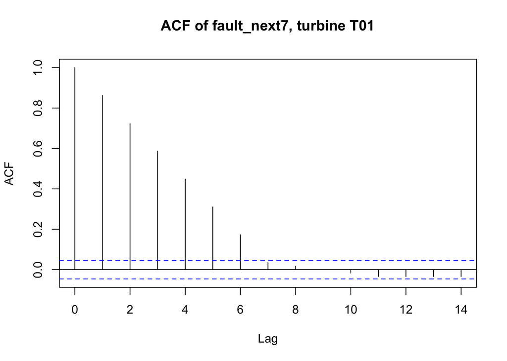

```r
set.seed(my_seed)
# rows are not independent: fault_next7 comes in runs of days
a <- acf(meltem$fault_next7[meltem$turbine == "T01"], lag.max = 14, main = "ACF of fault_next7, turbine T01")
```

```r
round(a$acf[2:9], 2)                                          # lags 1 ... 8 days
```

```
## [1] 0.86 0.72 0.59 0.45 0.31 0.17 0.03 0.02
```

```r
# and all turbines share the same weather on the same day
cor(meltem$energy_mwh[meltem$turbine == "T01"], meltem$energy_mwh[meltem$turbine == "T03"])
```

```
## [1] 0.9283605
```

```r
# time-ordered split: train = 2020-2023 (past), test = 2024 (future).
# The 7 days before 2024 are not used: their label looks 7 days ahead, into the test year.
test_start <- as.Date("2024-01-01")
split <- meltem %>%
  filter(date < test_start - 7 | date >= test_start) %>%
  mutate(set = ifelse(date >= test_start, "test", "train")) %>%
  select(date, turbine, set)

# checks
split %>% left_join(meltem, by = c("date", "turbine")) %>% group_by(set) %>%
  summarise(rows = n(), share = round(n() / nrow(split), 3), first = min(date), last = max(date),
            turbines = n_distinct(turbine), positives = sum(fault_next7), positive_rate = round(mean(fault_next7), 4))
```

```
## # A tibble: 2 × 8
##   set    rows share first      last       turbines positives positive_rate
##   <chr> <int> <dbl> <date>     <date>        <int>     <dbl>         <dbl>
## 1 test   4392 0.201 2024-01-01 2024-12-31       12        70        0.0159
## 2 train 17448 0.799 2020-01-01 2023-12-24       12       374        0.0214
```

#### Explanation (at most 250 words)

How did you build the two samples, why is this a fair split for *this* data, and which checks did you do?

The rows are not independent, so I decided not to use a random or stratified split. The target `fault_next7` appears in consecutive days because one repair creates 7 positive labels. For T01, the target ACF is 0.86 at lag 1 and drops to around zero after 7 days. With a random split, days from the same fault event would appear in both training and testing, so the model could simply copy the label of the neighbouring day and the test score would be too optimistic. Turbines also share weather conditions (daily energy correlation of 0.93 between T01 and T03), so all turbines of one day should be in the same set.

I therefore used a time-based split: training on the past and testing on the future. The training period is 2020-01-01 to 2023-12-24 (17,448 rows), while the test set contains all of 2024 (4,392 rows, 20.1%), so it covers every season. I excluded the last 7 days of 2023 (84 rows) to avoid label leakage, since their target looks 7 days ahead into 2024.

I checked that both sets include all 12 turbines and have no overlapping dates. Training has 374 positive cases (2.14%), while testing has 70 (1.59%), which is enough to evaluate the model. Although the positive rate is slightly lower in 2024, I kept the split because that year simply had fewer repairs, and the goal is to evaluate how the model performs on future data.

### TASK 3: Time series components (7 points)

Build the series of the **average daily farm energy per month** from the original `meltem` table: for each day add up `energy_mwh` of the 12 turbines, then average these daily totals within every calendar month. You should get 60 values, from January 2020 to December 2024. As a check, the value of January 2020 is 119.9 MWh per day. Make it a monthly time series (`ts`) and decompose it with `stl`.

Draw the decomposition and evaluate it: what do the trend, the seasonal and the remainder components tell about the farm? Use the autocorrelation function (`acf`) to judge the remainder.

#### Answer

```r
monthly <- meltem %>%
  group_by(date) %>% summarise(farm = sum(energy_mwh)) %>%                    # daily farm total
  group_by(month = format(date, "%Y-%m")) %>% summarise(mwh = mean(farm))     # average per month
nrow(monthly); round(monthly$mwh[1], 1)                                       # 60 values, 119.9
```

```
## [1] 60
```

```
## [1] 119.9
```

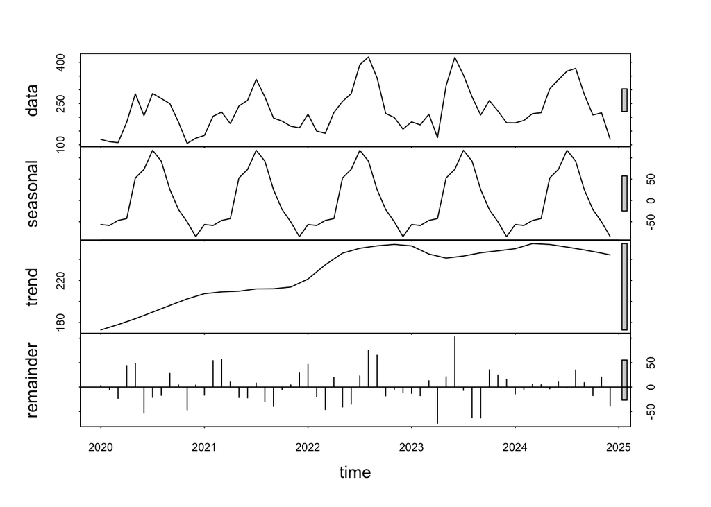

```r
energy_ts <- ts(monthly$mwh, start = c(2020, 1), frequency = 12)
dec <- stl(energy_ts, s.window = "periodic")
plot(dec)
```

```r
round(dec$time.series[1:12, "seasonal"])                    # seasonal effect, January ... December
```

```
##  [1] -56 -59 -47 -43  53  73 118  92  25 -21 -50 -85
```

```r
round(aggregate(dec$time.series[, "trend"], FUN = mean))    # trend, mean per year
```

```
## Time Series:
## Start = 2020
## End = 2024
## Frequency = 1
## [1] 189 211 245 246 251
```

```r
round(apply(dec$time.series, 2, sd), 1)                     # size of the three components
```

```
##  seasonal     trend remainder
##      66.4      25.5      35.1
```

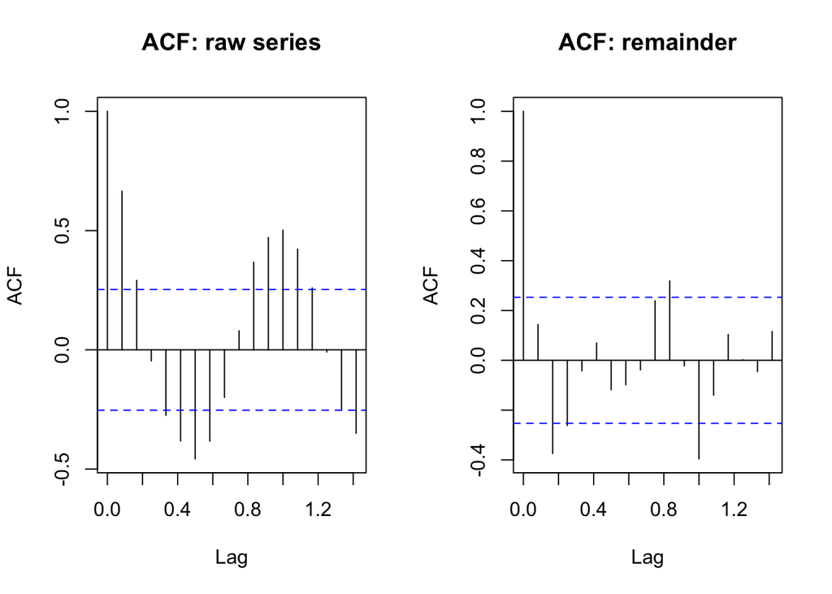

```r
par(mfrow = c(1, 2))                                        # two plots side by side; lag axis in years (1.0 = 12 months)
acf(energy_ts, main = "ACF: raw series")
acf(dec$time.series[, "remainder"], main = "ACF: remainder")
```

```r
par(mfrow = c(1, 1))
round(acf(dec$time.series[, "remainder"], plot = FALSE)$acf[2:13], 2)  # remainder, lags 1 ... 12 months
```

```
##  [1]  0.14 -0.37 -0.26 -0.04  0.07 -0.12 -0.10 -0.04  0.24  0.32 -0.02 -0.40
```

#### Explanation (at most 250 words)

Describe the trend, the seasonality and the remainder, and say what the `acf` plot shows and what that means.

The series has 60 values, and January 2020 is 119.9 MWh/day. I used `s.window = "periodic"`, the same seasonal pattern every year: five years are too short to estimate a changing one.

**Seasonality** is the largest component (sd 66.4). It peaks in July (+118) and August (+92) and is lowest in December (−85), so summer and winter differ by about 200 MWh/day. This is the *meltem*, the strong summer wind of the Aegean: the farm produces most of its energy in May–September.

**Trend** (sd 25.5) rises from 189 MWh/day in 2020 to 245 in 2022, then stays flat (246 and 251). Production grew by about 30%, then stabilised.

**Remainder** (sd 35.1) is not small: it is larger than the trend. Some months are much better or worse than trend plus season.

**ACF.** The raw series shows a seasonal wave with a peak at lag 12 (one year). In the remainder this positive peak is gone, so the decomposition removed most of the seasonality. But the remainder is not white noise: lags 2 and 3 are −0.37 and −0.26, outside the blue band, so a strong month tends to be followed by weaker months two or three months later. Lag 12 is now negative (−0.40): a fixed seasonal pattern cannot follow the differences between the summers of the five years, so they stay in the remainder. A model of this series should therefore also use past months (lags), not only trend and season.

### TASK 4: Exploratory analysis (7 points)

The farm has two turbine models with different rated power. The file does not say which turbine has which model. Use the whole original `meltem` table.

**4.1** Find out from the data which turbines belong to the larger model. Draw the plots that show it, and write the ids of the turbines of the larger model in your explanation.

**4.2** Compute the correlation between `rotor_rpm` and `gbx_oil_c` (i) over all rows, (ii) over the rows of the turbines of the larger model, (iii) over the rows of the turbines of the smaller model. Draw one scatter plot of `rotor_rpm` against `gbx_oil_c` that shows the finding.

**4.3** Evaluate your findings.

#### Answer

```r
# 4.1 rated power is the ceiling of the daily energy
per_turbine <- meltem %>% group_by(turbine) %>%
  summarise(max_energy = max(energy_mwh), mean_energy = round(mean(energy_mwh), 1), mean_rpm = round(mean(rotor_rpm), 1)) %>%
  arrange(desc(max_energy))
per_turbine
```

```
## # A tibble: 12 × 4
##    turbine max_energy mean_energy mean_rpm
##    <chr>        <dbl>       <dbl>    <dbl>
##  1 T09           69.9        23.3      6.8
##  2 T11           69.4        25.3      6.9
##  3 T02           69.1        24        6.8
##  4 T06           67.1        22.6      6.7
##  5 T05           64.4        21.9      6.6
##  6 T10           48          16.8     11.1
##  7 T07           47.6        16.6     11.1
##  8 T08           45.9        17       11.1
##  9 T12           45.2        14.9     10.7
## 10 T01           44.6        15.4     10.8
## 11 T03           43.3        16.2     11
## 12 T04           42.7        15.1     10.8
```

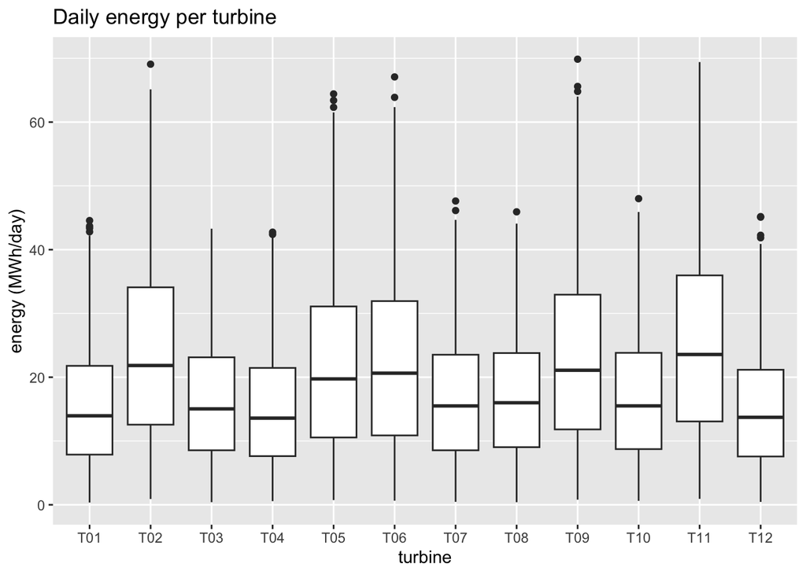

```r
ggplot(meltem, aes(turbine, energy_mwh)) + geom_boxplot() +
  labs(title = "Daily energy per turbine", y = "energy (MWh/day)")
```

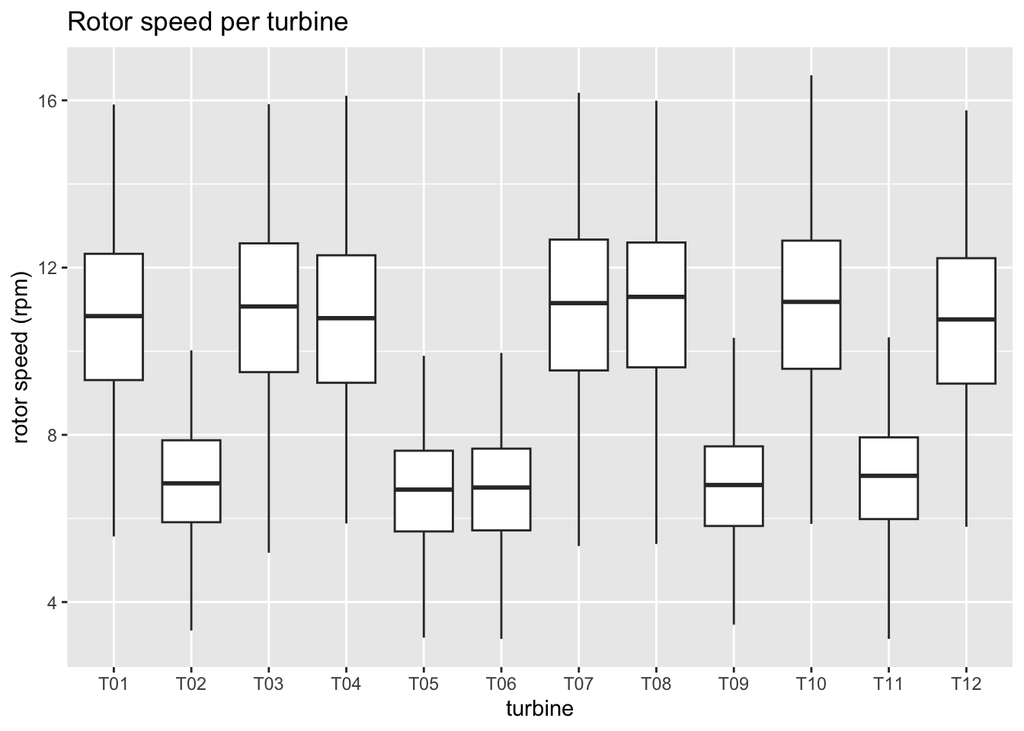

```r
ggplot(meltem, aes(turbine, rotor_rpm)) + geom_boxplot() +
  labs(title = "Rotor speed per turbine", y = "rotor speed (rpm)")
```

```r
big_ids <- per_turbine$turbine[per_turbine$max_energy > 55]   # 55: in the empty gap between 48 and 64 MWh/day
big_ids
```

```
## [1] "T09" "T11" "T02" "T06" "T05"
```

```r
# 4.2 correlations: all rows, then per model
m4 <- meltem %>% mutate(model = ifelse(turbine %in% big_ids, "larger", "smaller"))
round(cor(m4$rotor_rpm, m4$gbx_oil_c), 2)
```

```
## [1] -0.37
```

```r
m4 %>% group_by(model) %>%
  summarise(r = round(cor(rotor_rpm, gbx_oil_c), 2), mean_rpm = round(mean(rotor_rpm), 1), mean_oil = round(mean(gbx_oil_c), 1))
```

```
## # A tibble: 2 × 4
##   model       r mean_rpm mean_oil
##   <chr>   <dbl>    <dbl>    <dbl>
## 1 larger   0.65      6.8     66.5
## 2 smaller  0.67     10.9     39.4
```

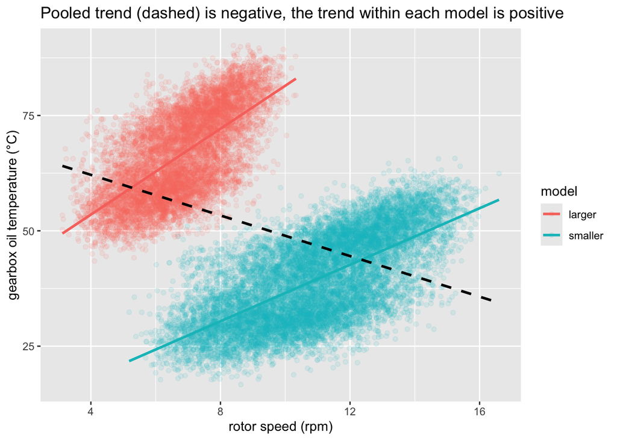

```r
# one scatter plot: colour = model, solid lines = trend within each model, dashed line = trend over all rows
ggplot(m4, aes(rotor_rpm, gbx_oil_c, colour = model)) + geom_point(alpha = 0.1) +
  geom_smooth(method = "lm", formula = y ~ x, se = FALSE) +
  geom_smooth(aes(group = 1), method = "lm", formula = y ~ x, se = FALSE, colour = "black", linetype = 2) +
  labs(title = "Pooled trend (dashed) is negative, the trend within each model is positive",
       x = "rotor speed (rpm)", y = "gearbox oil temperature (°C)")
```

#### Explanation (at most 250 words)

Which turbines are the larger model, and how did you recognise them? What do the three correlations tell about the relation between rotor speed and gearbox oil temperature? What would you tell the maintenance engineers of the farm?

**4.1** The larger model is **T02, T05, T06, T09 and T11**. The rated power is the ceiling of the daily energy. These five turbines reach 64–70 MWh/day, and the other seven stop at 43–48 MWh/day. No turbine falls in between: the energy boxplot shows two clear groups. The rotor speed boxplot shows the same five turbines: they turn slowly (mean 6.6–6.9 rpm), and the other seven turn at 10.7–11.1 rpm.

**4.2** Over all rows r = **−0.37**. Within the larger model r = **+0.65** and within the smaller model r = **+0.67**. The sign flips: this is Simpson’s reversal. Within each model, a faster rotor (more wind, more load) means hotter gearbox oil. But the larger model turns slowly *and* runs hot (mean oil 66.5 °C at 6.8 rpm), while the smaller model turns fast and runs cool (39.4 °C at 10.9 rpm). This difference between the groups produces the negative pooled trend (dashed line).

**4.3** The pooled correlation is misleading: the model of the turbine is the third variable that explains it. The real relation is positive and almost equal in both models, but the level of the oil temperature depends on the model. Maintenance engineers should judge the gearbox oil temperature **separately for each model**, for example with alarm limits per model and relative to the rotor speed. With one limit for the whole farm, the larger turbines would always look too hot, and an overheating smaller turbine would never be noticed.

### Submission (do not change)

Submit this Rmd file only. When it is knitted, the chunk below collects `imputed` and `split` (it writes `imputed_<your id>.csv` and `split_<your id>.csv`). The table only tells whether the two objects are found in the required format.

| item | status |
| --- | --- |
| Task 1: `imputed` is ready | yes |
| Task 2: `split` is ready | yes |